# Workshop: Modeling disease spread

2022-08-31

## Why model?

Models, broadly defined, are useful in several ways:

- **formalizing thinking about how a system works**
  - boxes and arrows
  - simple mathematical representation
  - finer, more complex representation of processes and variables
- **identifying data gaps** (as one tries to parameterize)

## Why model?

- **understand consequences of model structure / assumptions** (*run the model*)
  - examining counterfactuals
  - identify influential parameters or processes (sensitivity analyses, comparing models with different structures formally)
  - sort among models / underlying hypotheses (which models best match reality / fit data?)
  - make quantitative predictions/projections/statements about likely dynamics/outcomes/etc. (running the model, but with more quantitative care/flare)

## Our goals today

1. Describe simple “compartment” model as boxes & arrows and differential equations
2. Implement the model in R with the `simecol` package

## Part 1: Model structure

We are interested in describing the dynamics and outcome of an epidemic in a closed population.

We will thus focus on:

- the fractions of the hosts population that are in the susceptible class (\(S\)) or the infected class (\(I\))
  - These are the “state variables”
- track the flow of these fractions of the population between classes

## Part 1: Model structure

### assumptions

We will ignore:

- immunity for simplicity and because it does not seem to happen in tadpoles, which is mostly what I think about.
- dynamics other than infection, recovery to susceptibility, and death due to infection. That is, no immigration, emigration, birth, or death not due to disease.

We will assume

- individuals within a class (\(S\) or \(I\)) are identical.
- transmission occurs by direct contact

## Part 1: Model structure

### the forces at work

Susceptible individuals are

- **infected** by contact with infected individuals

Infected animals either

- **die** or
- **recover** to \(S\) class

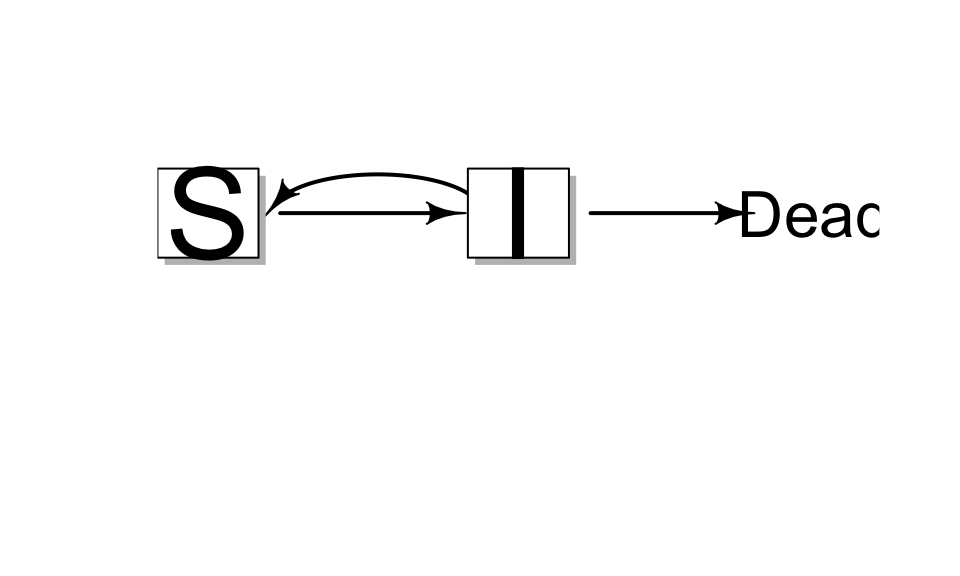

## Part 1: Model structure

### thinking about rates

Susceptible individuals are

- **infected** at per capita rate \(\beta I\)

Infected animals either

- **die** at per capita rate \(\alpha\), or
- **recover** to \(S\) class at per capita rate \(\gamma\)

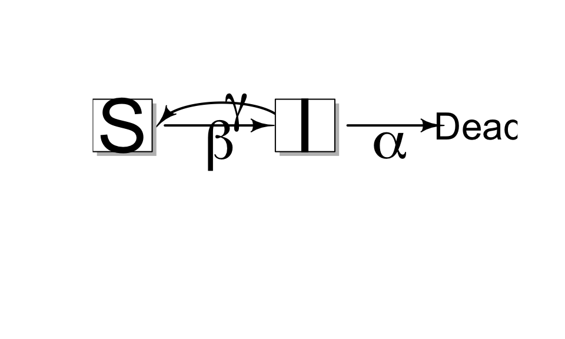

## Part 1: Model structure

### writing ODEs

We can write ordinary differential equations (ODEs) to describe the *rate* at which we gain/lose \(S\) and \(I\).

\[ \begin{align} \frac{dS}{dt} &= -\beta S I + \gamma I \\ \frac{dI}{dt} &= \beta S I - \gamma I - \alpha I \end{align} \]

NB: If we add up the two equations all terms cancels out except \(-\alpha I\).

\(\rightarrow\) population will decline as hosts are lost to disease-induced mortality (=virulence)

## Part 1: Model structure

### the allure of simple ODEs

The good:

- ODEs are fairly simple to write out (or convert from boxes and arrows)
- very powerful
- (relatively) easy to adapt to

The bad:

- you can easily make a model that you have no hope of understanding or parameterizing

## Part 1: Model structure

### the allure of simple ODEs

> A model does nothing but expose the consequences of the assumptions upon which it is based. – Schauber & Ostfeld RS (2002) Ecol Appl 12:1142-1162

## Part 2: Implementing our model in R

### `simecol`

`simecol` to:

1. organize our model and stuff (e.g., parameters, initial conditions)
2. solve (=run) the model

`tidyverse` to deal with the data output from model runs.

## Part 2: Implementing our model in R

### `simecol`

```r
library(simecol) # for running model
```

```r
library(tidyverse) # for data wrangling & plotting
```

## Part 2: Implementing our model in R

### building up the model

The basic structure of a `simecol` model of ODEs is:

```r
SI <- odeModel(
          main = function (time, init, parms, ...) {
            ### The actual model will go here
          },
          parms = c(), #named vector of parameters
          times = c(), # time points over which to solve the model
          init = c(), # initial values for the variables
          solver = "rk4" # the function that does the solving
)
```

## Part 2: Implementing our model in R

```r
SI <- odeModel(
          main = function (time, init, parms, ...) {
            S <- init["S"]
            I <- init["I"]
            with(as.list(parms),  {
              ### The actual model will go here
            })
          },
          parms = c(), #named vector of parameters
          times = c(), # time points over which to solve the model
          init = c(), # initial values for the variables
          solver = "rk4" # the function that does the solving
)
```

## Part 2: Implementing our model in R

```r
SI <- odeModel(
          main = function (time, init, parms, ...) {
            S <- init["S"]
            I <- init["I"]
            with(as.list(parms),  {
              dS <- -beta*S*I + gamma*I
              dI <-  beta*S*I - gamma*I - alpha*I
              list(c(dS, dI))
            })
          },
          parms = c(), #named vector of parameters
          times = c(), # time points over which to solve the model
          init = c(), # initial values for the variables
          solver = "rk4" # the function that does the solving
)
```

## Part 2: Implementing our model in R

```r
SI <- odeModel(
          main = function (time, init, parms, ...) {
            S <- init["S"]
            I <- init["I"]
            with(as.list(parms),  {
              dS <- -beta*S*I + gamma*I
              dI <-  beta*S*I - gamma*I - alpha*I
              list(c(dS, dI))
            })
          },
          parms = c(beta=0.0005, gamma=0.02, alpha=0.05),
          times = c(from=1, to=90, by=1),
          init = c(S=500, I=1),
          solver = "rk4" # the function that does the solving
)
```

## Part 2: Implementing our model in R

### running the model

```r
SI <- sim(SI) # simulate or "run" the model
out(SI)  # accessor function
```

```
##    time         S          I
## 1     1 500.00000   1.000000
## 2     2 499.74808   1.197143
## 3     3 499.44669   1.432953
## 4     4 499.08623   1.714929
## 5     5 498.65525   2.051988
## 6     6 498.14015   2.454714
## 7     7 497.52481   2.935653
## 8     8 496.79012   3.509637
## 9     9 495.91350   4.194163
## 10   10 494.86836   5.009798
## 11   11 493.62347   5.980633
## 12   12 492.14229   7.134750
## 13   13 490.38233   8.504707
## 14   14 488.29437  10.127988
```

[output cut: 76 more lines]

## Part 2: Implementing our model in R

### running the model

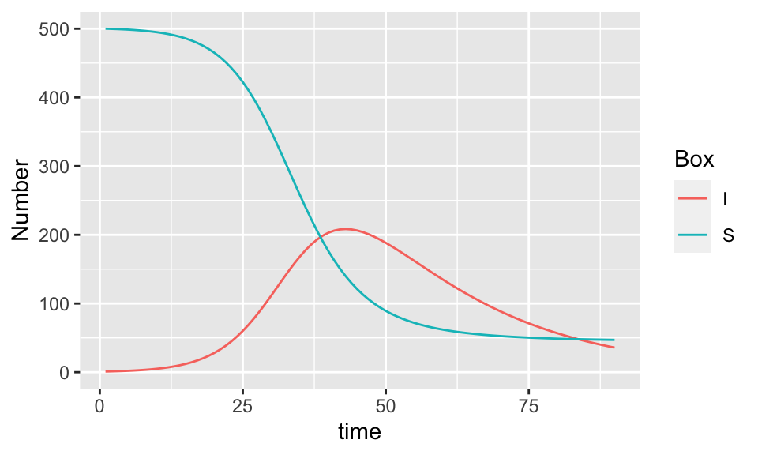

```r
out(SI) %>% # get the output from the model
  gather(key="Box", value="Number", S, I) %>% # turn it from wide to long
  ggplot(., aes(x=time, y=Number, color=Box)) + # construct the plot
  geom_line() # use a line to show the data
```

## Tweaking things

### futzing with parameters

```r
parms(SI)
```

```
##  beta gamma alpha
## 5e-04 2e-02 5e-02
```

```r
parms(SI)["beta"] <- 0.001 # twice as high
parms(SI)
```

```
##  beta gamma alpha
## 0.001 0.020 0.050
```

## Tweaking things

### futzing with parameters

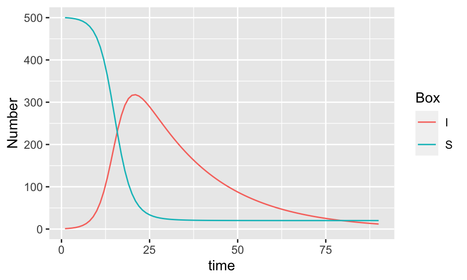

```r
out(sim(SI)) %>%
  gather(key="Box", value="Number", S, I) %>%
  ggplot(., aes(x=time, y=Number, color=Box)) +
  geom_line()
```

## Tweaking things

### futzing with initial variables & time series

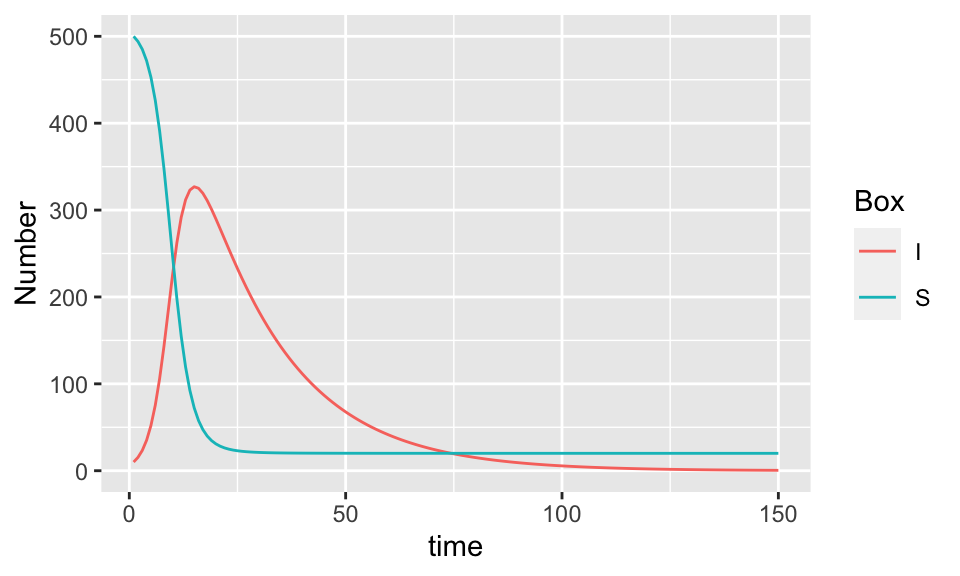

```r
init(SI)["I"] <- 10
times(SI)["to"] <- 150
out(sim(SI)) %>%
  gather(key="Box", value="Number", S, I) %>%
  ggplot(., aes(x=time, y=Number, color=Box)) +
  geom_line()
```

## Tweaking things

### creating composite variables

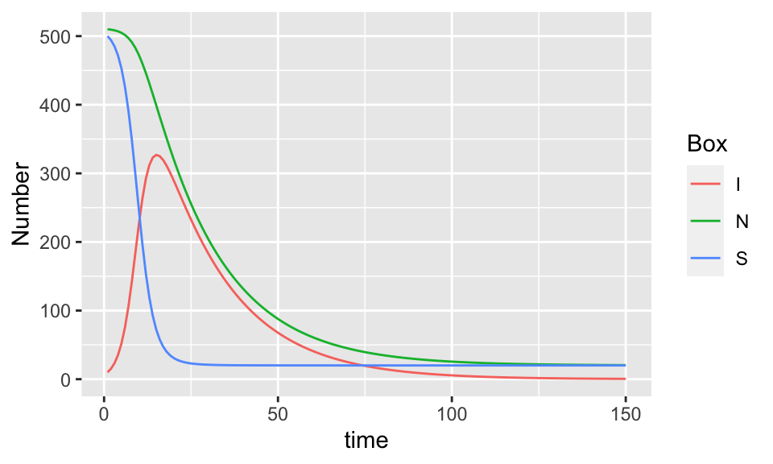

```r
out(sim(SI)) %>%
  mutate(N = S+I) %>% # create a new variable for N
  gather(key="Box", value="Number", S, I, N) %>% # plot it along with S & I
  ggplot(., aes(x=time, y=Number, color=Box)) +
  geom_line()
```

## Tweaking things

### creating composite variables

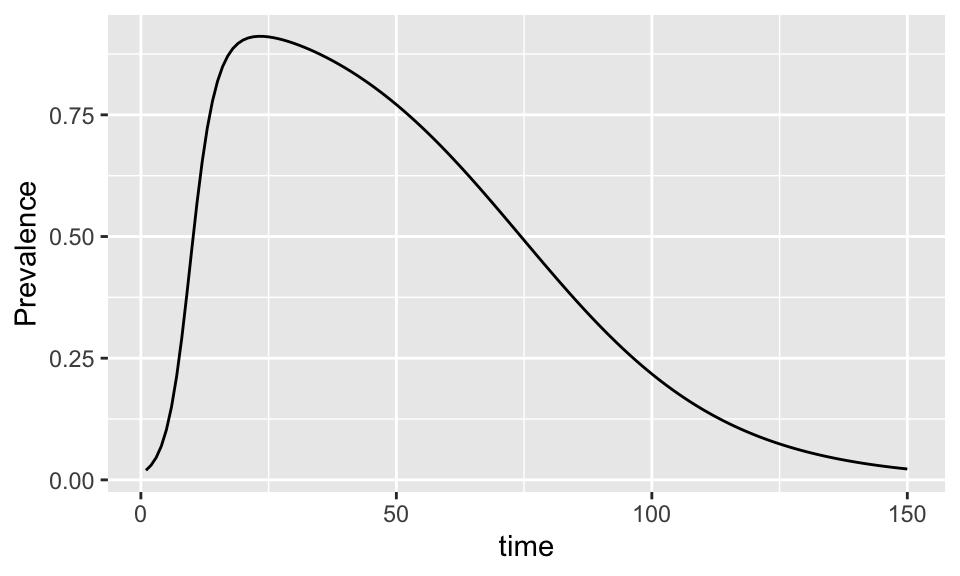

```r
out(sim(SI)) %>%
  mutate(N = S+I, # create a new variable for N
         Prevalence = I/N) %>% # then use it to calculate prevalence
  ggplot(., aes(x=time, y=Prevalence)) + # which will be plotted
  geom_line()
```

## Next steps and advice

### Transmission terms

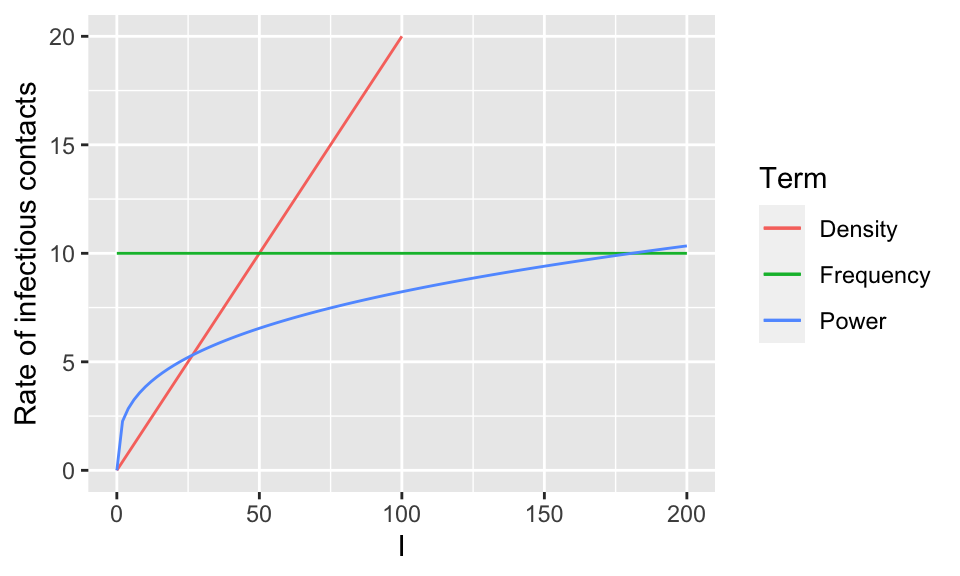

essential, but difficult to pin down emprically

## Next steps and advice

### density or numbers?

- Does the habitat/area stay the same or shrink?
- Does the population maintain a density (e.g., heard/aggregation)?
- What do you have data on?

## Next steps and advice

### check your units (aka dimensional analysis)

- Units on left (e.g., Number/time) must equal units on right
- So make sure units on variables and parameters cancel correctly

[figure not shown]

## Next steps and advice

### distributions of waiting times

- Constant rates \(\rightarrow\) exponential distribution of time in category

\(I_0 = 100\), \(\alpha = 0.05\), and \(S_0=0\).

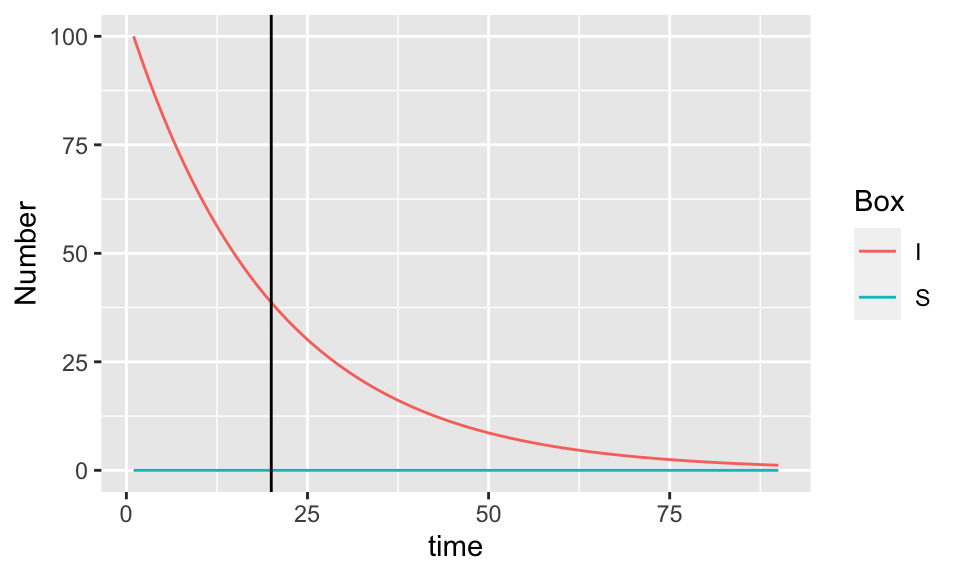

## Next steps and advice

### distributions of waiting times

- add intermediate class
  - \(E\)xposed-but-not-yet-infectious class (\(SEI\) model)
- break up \(I\) into \(n\) compartments, each flowing into the next
  - \(I_1 \rightarrow I_2, I_2 \rightarrow I_3, \dots, I_{n-1} \rightarrow I_n, I_n \rightarrow \text{death}\)

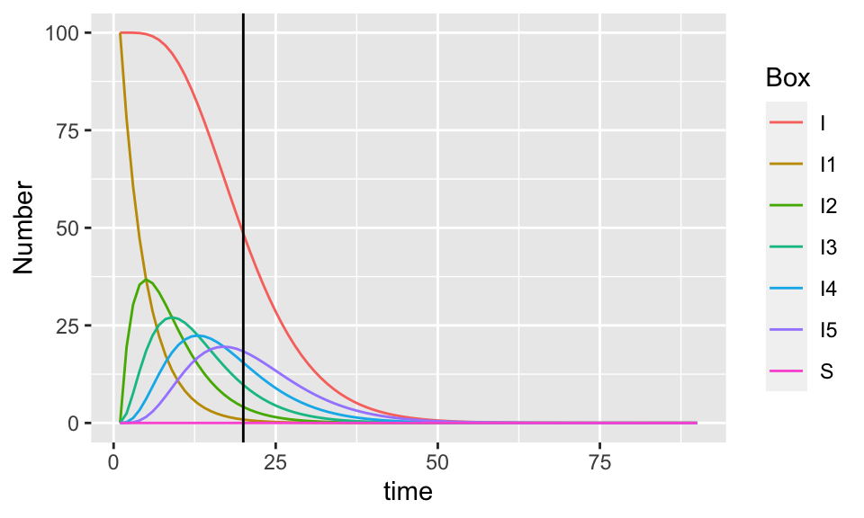